# Project Lost Piglet 2

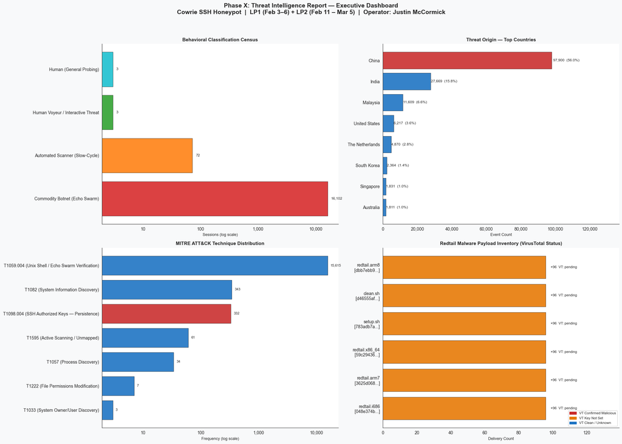

[output not shown]

[output cut: 74 more lines]

[output not shown]

```python
    # ── MITRE Detection Guidance ──────────────────────────────────────────────
    print(f'\n  {"DETECTION GUIDANCE — MITRE ATT&CK":─<{W-4}}')
    if cmd_df is not None and not cmd_df.empty and 'mitre_ttp' in cmd_df.columns:
        ttp_counts = cmd_df['mitre_ttp'].value_counts()
        print(f'  {"Technique":<50}  {"Events":>8}  {"Detection Rule"}')
        print(f'  {"-"*50}  {"-"*8}  {"-"*28}')
        detection_map = {
            'T1098': 'Alert on authorized_keys + chattr combination',
            'T1105': 'Block outbound wget/curl to unknown IPs',
            'T1082': 'Baseline then alert on uname/id burst (>10/min)',
            'T1074': 'Alert on cat/less against sensitive filenames',
            'T1059': 'Alert on hex-encoded echo in non-admin sessions',
            'T1003': 'Alert on /etc/shadow or /etc/passwd read',
            'T1222': 'Alert on chattr +i on system directories',
        }
        for tech, count in ttp_counts.head(8).items():
            tech_id = tech.split(' ')[0]
            rule = next((v for k, v in detection_map.items() if k in tech_id), 'Review logs')
            print(f'  {tech:<50}  {count:>8,}  {rule}')
    else:
        print('  MITRE data not available — run Phase VII first.')

    print('\n' + '═' * W + '\n')


# ─── EXECUTION BLOCK ─────────────────────────────────────────────────────────

try:
    # ── Gather upstream data with NameError guards ────────────────────────────
    def _safe_get(var_name):
        try:
            return eval(var_name)
        except NameError:
            return None

    _df            = _safe_get('df')
    _features_df   = _safe_get('features_df')
    _cmd_df        = _safe_get('cmd_df')
    _geo_df        = _safe_get('geo_df')
    _top_hassh_df  = _safe_get('top_hassh_df')
    _kill_chains   = _safe_get('kill_chains_df')
    _clusters_df   = _safe_get('clusters_df')
    _top_creds     = _safe_get('top_creds')
    _sess_seqs     = _safe_get('session_sequences')
    _ranked_doss   = _safe_get('ranked_dossier')

    # Prefer VT-enriched malware df; fall back to raw inventory
    # NOTE: cannot use 'or' — that calls DataFrame.__bool__() → ValueError.
    #       Use explicit None / .empty guards instead.
    _tmp = _safe_get('malware_vt_df')
    _malware_vt_df = (
        _tmp
        if (_tmp is not None and not getattr(_tmp, 'empty', True))
        else _safe_get('malware_samples_df')
    )

    # ── 1. IOC Aggregation ────────────────────────────────────────────────────
    _cmd_safe      = _cmd_df if _cmd_df is not None else pd.DataFrame()
    ioc_df         = extract_malware_iocs(_cmd_safe, _ranked_doss)
    lure_artifacts = extract_lure_artifacts(_cmd_safe, _sess_seqs)

    # ── 2. Executive Dashboard ────────────────────────────────────────────────
    plot_executive_dashboard(_features_df, _cmd_df, _geo_df, _malware_vt_df)

    # ── 3. CISO Strategic Brief ───────────────────────────────────────────────
    print_ciso_brief(
        df=_df,
        features_df=_features_df,
        malware_vt_df=_malware_vt_df,
        geo_df=_geo_df,
        top_hassh_df=_top_hassh_df,
        clusters_df=_clusters_df,
        lure_artifacts=lure_artifacts,
    )

    # ── 4. SOC Tactical Brief ─────────────────────────────────────────────────
    print_soc_brief(
        ioc_df=ioc_df,
        kill_chains_df=_kill_chains,
        top_hassh_df=_top_hassh_df,
        top_creds_df=_top_creds,
        lure_artifacts=lure_artifacts,
        cmd_df=_cmd_df,
    )

except NameError as e:
    logger.error("Phase X: Missing upstream variable — %s. "
                 "Ensure Phases I–IX have been executed.", e)
except Exception as e:
    logger.error("Phase X: Unexpected error — %s: %s. "
                 "Check upstream DataFrames for None/empty state.", type(e).__name__, e)
    raise
```

## **About the Author**

Justin McCormick is a cybersecurity and threat intelligence practitioner with a background in military intelligence operations and applied analytics. His professional experience spans operational intelligence collection - combining analytic tradecraft with data-driven methodologies to better understand adversarial behavior and deliver these actionable insights to stakeholders.

This project reflects a deliberate effort to bridge intelligence analysis with modern machine learning workflows to develop proprietary tooling to assist with personal and professional research objectives. While contemporary large language models and AI-assisted development tools were leveraged to accelerate architectural ideation and prototyping, all modeling decisions, feature engineering strategies, visualizations, and analytical interpretations were independently validated as well as iteratively refined. The intent was not automation for its own sake, but disciplined augmentation — using modern tools to keep pace with the current threat landscape while preserving critical thinking and technical ownership.

Justin is particularly interested in the intersection of threat intelligence, cybersecurity operations across all domains (Enterprise, ICS/OT, Mobile), as well as emerging technologies and how these capabilities are wielded by adversaries - to include applied artificial intelligence. His long-term objective is to contribute meaningfully to the general understanding of the ever-evolving threat environment, design secure and scalable systems to bolster security efforts while mentoring the next generation of analysts and engineers through practical instruction and applied research.

This notebook represents both a technical exploration and a step toward that broader mission.

If you wondering about the project title - "Lost Piglet?"

See the Dana Carvey clip below, as this was stuck in my head throughout the project's ideation. The sketch may be old, but I can assure the reader: "it's a good one - Piglet gets Lost."

[Dana Carvey - "Get a 100 year old man"](https://www.youtube.com/watch?v=X-AZy2W0qKg)